# BIOS 667 - Lecture 8: Mixed-Effects Models (Ch. 8)

Fitzmaurice, Laird & Ware (2011) - Applied Longitudinal Data Analysis

Naim Rashid

## Lecture Objectives

By the end of this lecture, you will be able to:

- Distinguish between marginal (GEE) and subject-specific (mixed-effects) approaches
- Formulate random-intercept and random-slope models for longitudinal data
- Understand how random effects induce covariance structures (CS, nonstationary)
- Apply shrinkage/EBLUP concepts for subject-specific predictions
- Choose between ML and REML for appropriate model comparisons

**Note**

**Reading.** FLW Ch. 8 (8.1-8.10). **Assessed by:** HW3 (LME with CS/AR(1)/UN covariance; marginal vs conditional interpretation) and the longitudinal-modeling component of the final project.

## Roadmap

| Section | Topics |
| --- | --- |
| **Foundations** | Why mixed-effects? RI vs RS models |
| **Estimation** | ML/REML, BLUPs, shrinkage |
| **TLC Application** | Data wrangling, model fitting, diagnostics |
| **Model Selection** | Comparing structures, boundary tests |
| **Advanced Topics** | Heterogeneous variances, AR(1), splines |
| **Summary** | Reporting checklist, practical guidance |

**Note**

**Pacing (2 class periods).** Day 1 (Part I): foundations through BLUPs and shrinkage, plus the core RI/RS fits on the TLC data. Day 2 (Part II): heterogeneous variances, AR(1), diagnostics, testing, and practical guidance.

## Prerequisites / recall

Before this lecture you should be able to:

- Describe the CS, AR(1), and UN covariance structures and what each assumes (Ch. 7).
- Interpret a marginal (population-average) regression coefficient.
- Fit a basic linear model in R and read its `summary()` output.

## Notation reference

| Symbol | Meaning |
| --- | --- |
| $Y_{ij}$ | response for subject $i$ at occasion $j$ (scalar) |
| $\mathbf{Y}_i$ | response vector for subject $i$ $(n_i \times 1)$ |
| $\mathbf{X}_i,\ \boldsymbol\beta$ | fixed-effect design $n_i \times p$ and coefficients |
| $\mathbf{Z}_i,\ \mathbf{b}_i$ | random-effect design and random effects, $\mathbf{b}_i \sim N(0, G)$ |
| $G$ | between-subject random-effects covariance (FLW’s letter, Ch. 8) |
| $R_i$ | within-subject residual covariance, $\boldsymbol\varepsilon_i \sim N(0, R_i)$ |
| $\Sigma_i = \mathbf{Z}_i G \mathbf{Z}_i^\top + R_i$ | marginal (total) covariance $\operatorname{Cov}(\mathbf{Y}_i)$ for subject $i$ |
| $\rho$ | correlation parameter (AR(1), exchangeable) |

Indices: $i$ subject $1,\dots,N$; $j$ occasion/time $1,\dots,n_i$ ($n$ when balanced); $k$ state (transition models); $g$ group. **Bold** = vector or matrix.

# Part I (Day 1): Models, Fitting, and Interpretation

## Why Mixed-Effects?

Longitudinal data: same person measured repeatedly leads to **correlated** outcomes.

Mixed-effects = fixed effects (population-average) + **random effects** (person-specific deviations).

## What Mixed-Effects Captures

| Feature | Description |
| --- | --- |
| Between-subject heterogeneity | Different baselines/slopes across individuals |
| Within-subject correlation | Implied by shared random effects |
| Unbalanced designs | Handles varying numbers of observations per subject |
| Mistimed visits | Continuous time naturally accommodated |

## Subject-Specific vs Marginal Views

“Marginal” vs “subject-specific” is a contrast of **estimands**, not methods. The LME delivers both:

| Estimand | Quantity | From the LME |
| --- | --- | --- |
| **Subject-specific** | $E(Y_i \mid b_i) = X_i\boldsymbol\beta + Z_i b_i$ | Conditional on the subject’s $b_i$ |
| **Marginal** | $E(Y_i) = X_i\boldsymbol\beta$, $\operatorname{Cov}(Y_i) = Z_i G Z_i^\top + \sigma^2 I$ | Averaging over $b_i$ (FLW pp. 190-191) |

Averaging the subject-specific mean over $b_i \sim N(0, G)$ gives the marginal mean $X_i\boldsymbol\beta$, so the LME **also** has a marginal interpretation. GEE is one way to target that marginal mean directly (with robust SEs); the LME targets it while also predicting subject trajectories and leveraging all available data under MAR.

## Model Building Blocks

Let $Y_{ij}$ be the response for subject $i$ at time $t_{ij}$.

## Random-Intercept (RI) Model

$$Y_{ij} = \beta_0 + X_{ij}\boldsymbol\beta + b_{0i} + \varepsilon_{ij}$$

where:

- $b_{0i} \sim N(0, \sigma_b^2)$ is the subject-specific intercept
- $\varepsilon_{ij} \sim N(0, \sigma^2)$ is the residual error

## Random-Slope (RS) Model

$$Y_{ij} = \beta_0 + \beta_1 t_{ij} + X_{ij}\boldsymbol\beta + b_{0i} + b_{1i} t_{ij} + \varepsilon_{ij}$$

where the random effects follow:

$$\begin{pmatrix} b_{0i} \\ b_{1i} \end{pmatrix} \sim N\!\left(\mathbf{0}, G\right), \quad
G = \begin{pmatrix} \sigma_{b0}^2 & \sigma_{b01} \\ \sigma_{b01} & \sigma_{b1}^2 \end{pmatrix}$$

## Implied Covariance (RI Model)

For the random-intercept model:

$$\mathrm{Var}(Y_{ij}) = \sigma_b^2 + \sigma^2$$

The shared random intercept $b_{0i}$ is the only thing two observations on subject $i$ have in common, so the off-diagonal covariance is

$$\mathrm{Cov}(Y_{ij}, Y_{ik}) = \sigma_b^2 \quad (j \ne k)$$

Dividing by the variance gives the correlation, which is the same for every pair of times:

$$\mathrm{Corr}(Y_{ij}, Y_{ik}) = \frac{\sigma_b^2}{\sigma_b^2 + \sigma^2} \quad \text{(Compound Symmetry)}$$

## Implied Covariance (RS Model)

For the random-slope model the implied variance changes with time (nonstationary):

$$\mathrm{Var}(Y_{ij}) = \sigma_{b0}^2 + 2\, t_{ij}\, \sigma_{b01} + t_{ij}^2\, \sigma_{b1}^2 + \sigma^2$$

This is a quadratic in $t_{ij}$: trajectories **fan out** (or in) over time, unlike the constant variance of compound symmetry. This is the nonstationary, “linear-in-time” covariance shown in the RI+RS row of the Link to Chapter 7 table below (it is introduced here, not in Ch. 7).

## RI vs RS: When and Why

| Model | Use When |
| --- | --- |
| **RI** | Subjects have different baselines but common trajectory shape |
| **RS** | Subjects have different **rates of change**; trajectories fan in/out |

If slopes vary across persons (common in biology), RS is often essential.

## Two-Stage Random Effects Formulation (FLW 8.4)

FLW motivate the LME model in two stages, which makes clear where the random effects come from:

- **Stage 1 (within-subject):** $\mathbf{Y}_i = \mathbf{Z}_i \boldsymbol\beta_i + \boldsymbol\varepsilon_i$, with $\boldsymbol\varepsilon_i \sim N(0, R_i)$. Each subject follows their own regression with coefficients $\boldsymbol\beta_i$.
- **Stage 2 (between-subject):** $\boldsymbol\beta_i = \mathbf{A}_i \boldsymbol\beta + \mathbf{b}_i$, with $\mathbf{b}_i \sim N(0, G)$. Here $\mathbf{A}_i$ is a known between-subject design matrix linking each subject’s coefficients to the population means $\boldsymbol\beta$ (often an identity, or a map of subject-level covariates). The subject-specific coefficients vary around $\boldsymbol\beta$.

Substituting Stage 2 into Stage 1 gives the familiar single-equation form

$$\mathbf{Y}_i = \mathbf{X}_i \boldsymbol\beta + \mathbf{Z}_i \mathbf{b}_i + \boldsymbol\varepsilon_i,
\qquad \Sigma_i = \mathbf{Z}_i G \mathbf{Z}_i^\top + R_i .$$

> The random-intercept and random-slope models are special cases: the two-stage view simply makes explicit that $G$ is the **between-subject covariance** of the $\mathbf{b}_i$.

## The Link to Chapter 7

| Random Effects | Implied Covariance |
| --- | --- |
| RI only | Compound Symmetry (CS) |
| RI + RS | Linear-in-time covariance (nonstationary) |

Mixed-effects give **parsimonious, interpretable** $\Sigma_i$ via random effects rather than directly parameterizing $\Sigma_i$.

**Check Your Understanding: Random Effects Basics**

1. In the random-intercept model, what is the implied correlation between two observations $Y_{ij}$ and $Y_{ik}$ from the same subject?
2. When would you choose a random-slope model over a random-intercept model?
3. A random-intercept model is equivalent to which covariance pattern from Chapter 7?

**Answers:**

1. $\text{Corr}(Y_{ij}, Y_{ik}) = \frac{\sigma_b^2}{\sigma_b^2 + \sigma^2}$. This is the intraclass correlation (ICC), representing the proportion of total variance attributable to between-subject differences.
2. When you expect subjects to have different **rates of change** over time, not just different starting points. Visual signs include trajectories that “fan out” or cross over time in spaghetti plots.
3. Compound Symmetry (CS). The random intercept induces constant correlation between any two time points for the same subject.

## Estimation Overview

| Method | Use For |
| --- | --- |
| **ML** | Comparing **different fixed effects** |
| **REML** | Comparing **different random-effects structures** (same fixed effects) |

Mixed-model equations (Henderson) yield **BLUPs** of random effects; with unknown variance components they become **EBLUPs** (empirical BLUPs, the FLW term for predicted random effects: BLUPs computed using the *estimated* variance components rather than known ones).

## Shrinkage Intuition (EBLUP)

**Borrowing strength**: subject-specific intercepts/slopes are **pulled** toward population means.

Shrinkage is stronger when:

- Subject has **few** measurements
- Measurement error $\sigma^2$ is **large**
- Random-effect variance is **small**

This prevents overfitting noisy within-subject patterns.

## TLC Data Setup

```r
library(dplyr); library(tidyr); library(nlme); library(ggplot2); library(emmeans)

path <- "../../data/tlc.csv"
tlc_wide <- read.csv(path, check.names = FALSE, stringsAsFactors = FALSE)
names(tlc_wide) <- trimws(names(tlc_wide))

tlc <- tlc_wide %>%
  rename(
    id  = ID,
    trt = `Treatment Group`,
    w0  = `Lead Level Week 0`,
    w1  = `Lead Level Week 1`,
    w4  = `Lead Level Week 4`,
    w6  = `Lead Level Week 6`
  ) %>%
  mutate(trt = factor(trt, levels = c("P","A"), labels = c("Placebo","Succimer"))) %>%
  pivot_longer(c(w0,w1,w4,w6), names_to = "wk", values_to = "y") %>%
  mutate(
    time     = recode(wk, w0="0", w1="1", w4="4", w6="6"),
    time_f   = factor(time, levels = c("0","1","4","6")),
    time_num = as.numeric(as.character(time)),
    id       = factor(id),
    group    = trt
  ) %>%
  select(id, group, time_f, time_num, y) %>%
  arrange(id, time_num)

stopifnot(all(!is.na(tlc$y)))
dplyr::count(tlc, id)
```

## TLC Data Setup

```
# A tibble: 100 × 2
   id        n
   <fct> <int>
 1 1         4
 2 2         4
 3 3         4
 4 4         4
 5 5         4
 6 6         4
 7 7         4
 8 8         4
 9 9         4
10 10        4
# ℹ 90 more rows
```

## TLC Visuals: Spaghetti Plot

```r
ggplot(tlc, aes(time_num, y, group = id, color = group)) +
  geom_line(alpha = 0.25) +
  stat_summary(aes(group = group), fun = mean, geom = "line", linewidth = 1.1) +
  labs(title = "Lead levels over time (TLC)", x = "Week", y = "Lead") +
  theme_minimal() + guides(color = guide_legend(title = "Group"))
```

## TLC Visuals: Spaghetti Plot

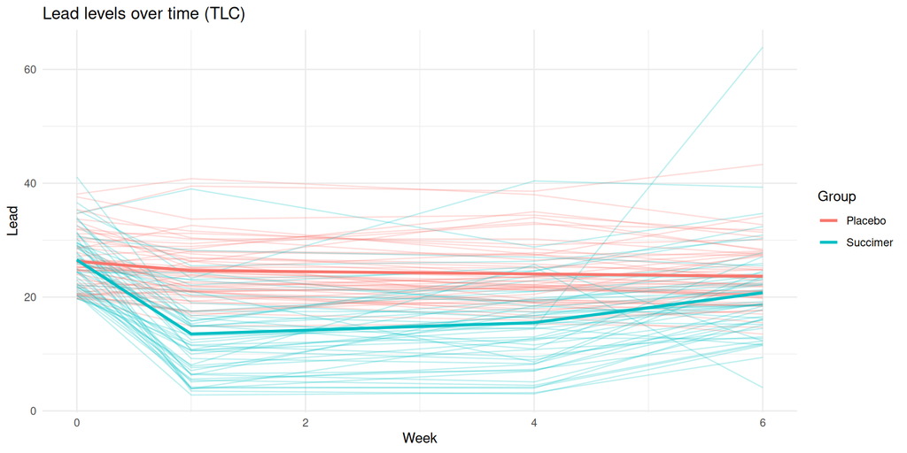

## Random-Intercept Model (RI)

```r
lme_ri <- lme(y ~ group * time_f, random = ~ 1 | id, data = tlc, method = "REML")
summary(lme_ri)$tTable[1:8, , drop = FALSE]
```

## Random-Intercept Model (RI)

```
                        Value Std.Error  DF    t-value      p-value
(Intercept)            26.272 0.9370175 294 28.0378980 4.595088e-85
groupSuccimer           0.268 1.3251428  98  0.2022424 8.401465e-01
time_f1                -1.612 0.8428574 294 -1.9125418 5.677827e-02
time_f4                -2.202 0.8428574 294 -2.6125416 9.449112e-03
time_f6                -2.626 0.8428574 294 -3.1155923 2.017079e-03
groupSuccimer:time_f1 -11.406 1.1919804 294 -9.5689496 4.631638e-19
groupSuccimer:time_f4  -8.824 1.1919804 294 -7.4028065 1.411814e-12
groupSuccimer:time_f6  -3.152 1.1919804 294 -2.6443389 8.624648e-03
```

```r
VarCorr(lme_ri)
```

```
id = pdLogChol(1)
            Variance StdDev
(Intercept) 26.13987 5.112717
Residual    17.76021 4.214287
```

## Reading VarCorr Output: Random-Intercept Model

**How to Interpret VarCorr for RI Model**

The `VarCorr()` output shows:

| Row | Meaning | Interpretation |
| --- | --- | --- |
| `(Intercept)` under `id` | $\sigma_b$ (StdDev) and $\sigma_b^2$ (Variance) | **Between-subject SD**: How much subjects differ at baseline |
| `Residual` | $\sigma$ (StdDev) and $\sigma^2$ (Variance) | **Within-subject SD**: Variability around each subject’s trajectory |

**Derived quantities:**

- **ICC (intraclass correlation)** = $\frac{\sigma_b^2}{\sigma_b^2 + \sigma^2}$ = proportion of variance due to between-subject differences
- **Total variance** = $\sigma_b^2 + \sigma^2$

**Example interpretation:** If `VarCorr` shows (Intercept) StdDev = 8.5 and Residual StdDev = 5.2, then ICC = $8.5^2/(8.5^2 + 5.2^2) = 72.25/99.29 \approx 0.73$. About 73% of the total variance is between subjects.

## RI Model Specification

- **Fixed**: group x time (factor) = maximal mean for covariance selection
- **Random**: intercept only ($b_{0i}$)

## Random-Slope Model (RS)

A random slope needs **numeric** time (`time_num`) so each subject has a single slope coefficient. (We keep the factor `time_f` for the population mean in the next model; the consequence of mixing factor and numeric time for model comparison shows up on the AIC slide.)

```r
ctrl <- lmeControl(
  niterEM     = 200,
  msMaxIter   = 200,
  msMaxEval   = 400,
  tolerance   = 1e-6,
  returnObject= TRUE
)

lme_rs <- lme(y ~ group * time_num, random = ~ time_num | id, data = tlc, method = "REML", control = ctrl)
summary(lme_rs)$tTable
```

**Random coefficients** allow individual-specific baseline **and** slope.

**Note**

`ctrl` (defined above via `lmeControl`) just relaxes `nlme`’s convergence settings and is reused via `control = ctrl` in the later fits. If a fit warns about convergence this usually helps. Note that `returnObject = TRUE` returns the fit **even if it did not fully converge**, so always confirm the fit converged before trusting it.

## Random-Slope Model (RS)

```
                             Value Std.Error  DF    t-value      p-value
(Intercept)            25.68536264 0.8268135 298 31.0654847 1.854745e-95
groupSuccimer          -5.41872527 1.1692909  98 -4.6341978 1.104758e-05
time_num               -0.37213187 0.1766540 298 -2.1065573 3.599182e-02
groupSuccimer:time_num -0.05773626 0.2498265 298 -0.2311054 8.173915e-01
```

```r
VarCorr(lme_rs)
```

```
id = pdLogChol(time_num)
            Variance   StdDev    Corr
(Intercept) 14.8548089 3.8541937 (Intr)
time_num     0.1017498 0.3189825 1
Residual    33.1827562 5.7604476
```

## Reading VarCorr Output: Random-Slope Model

**How to Interpret VarCorr for RS Model**

The `VarCorr()` output for a random-slope model shows:

| Row | Meaning | Interpretation |
| --- | --- | --- |
| `(Intercept)` under `id` | $\sigma_{b0}$ | **Between-subject SD in intercepts**: How much starting points vary |
| `time_num` under `id` | $\sigma_{b1}$ | **Between-subject SD in slopes**: How much rates of change vary |
| `Corr` | $\rho_{01}$ | **Intercept-slope correlation**: Do high-baseline subjects change faster or slower? |
| `Residual` | $\sigma$ | **Within-subject residual SD**: Unexplained variability |

**Interpreting the correlation:**

- $\rho_{01} > 0$: Subjects with higher intercepts tend to have steeper slopes
- $\rho_{01} < 0$: Subjects with higher intercepts tend to have flatter (or declining) slopes
- $\rho_{01} \approx 0$: Baseline and rate of change are unrelated

**Note:** The intercept-slope correlation is easier to interpret when time is centered (e.g., at baseline or mid-study).

## RI vs RS: AIC/REML Comparison

```r
data.frame(
  model = c("RI (time_f)", "RS (time_num)"),
  AIC   = c(AIC(lme_ri), AIC(lme_rs)),
  logLik= c(logLik(lme_ri), logLik(lme_rs))
)
```

Not strictly comparable if fixed effects differ (time factor vs numeric): REML AIC compares random structures only when the fixed effects match (see Estimation Overview).

## RI vs RS: AIC/REML Comparison

```
          model      AIC    logLik
1   RI (time_f) 2480.621 -1230.311
2 RS (time_num) 2681.281 -1332.641
```

## Factor-Time Fixed Effects with RS Random

Strategy: keep **time as factor** in fixed effects (rich mean), use **time_num** in random part to permit RS.

```r
lme_rifs <- lme(y ~ group * time_f, random = ~ time_num | id, data = tlc, method = "REML", control = ctrl)
data.frame(
  model = c("RI", "RI+RS"),
  AIC   = c(AIC(lme_ri), AIC(lme_rifs)),
  logLik= c(logLik(lme_ri), logLik(lme_rifs))
)
```

## Factor-Time Fixed Effects with RS Random

```
  model      AIC    logLik
1    RI 2480.621 -1230.311
2 RI+RS 2471.239 -1223.620
```

## Interpreting Fixed Effects with RS

| Component | Interpretation |
| --- | --- |
| Fixed effects | Summarize **average** trajectory |
| Random effects | Capture **individual departures** |
| Interaction group x time | **Difference-in-change** averaged across subjects |

## EMMs for Contrasts at Planned Times

```r
emm_ri <- emmeans(lme_ri, ~ group | time_f)
pairs(emm_ri)
```

Same use of `emmeans` as in Ch. 7; SEs now reflect **random-effects** structure.

## EMMs for Contrasts at Planned Times

```
time_f = 0:
 contrast           estimate   SE df t.ratio p.value
 Placebo - Succimer   -0.268 1.33 98  -0.202  0.8401

time_f = 1:
 contrast           estimate   SE df t.ratio p.value
 Placebo - Succimer   11.138 1.33 98   8.405 <0.0001

time_f = 4:
 contrast           estimate   SE df t.ratio p.value
 Placebo - Succimer    8.556 1.33 98   6.457 <0.0001

time_f = 6:
 contrast           estimate   SE df t.ratio p.value
 Placebo - Succimer    2.884 1.33 98   2.176  0.0319

Degrees-of-freedom method: containment
```

## BLUPs: Subject-Specific Intercepts/Slopes

```r
re <- ranef(lme_rifs)
head(re)
```

**So what?** A wide spread of these intercept BLUPs $b_{0i}$ means substantial between-subject variation in baseline, consistent with a large $\sigma_{b0}$ in `VarCorr`: the histogram is the picture of that variance component. (The QQ-plot slide recomputes `re` from the same fit.)

## BLUPs: Subject-Specific Intercepts/Slopes

```
  (Intercept)    time_num
1   1.3275459  0.10983619
2   0.9802875  0.08112388
3   2.5109979  0.20778267
4  -0.8697587 -0.07197501
5  -7.1566619 -0.59223765
6  -5.9970622 -0.49627353
```

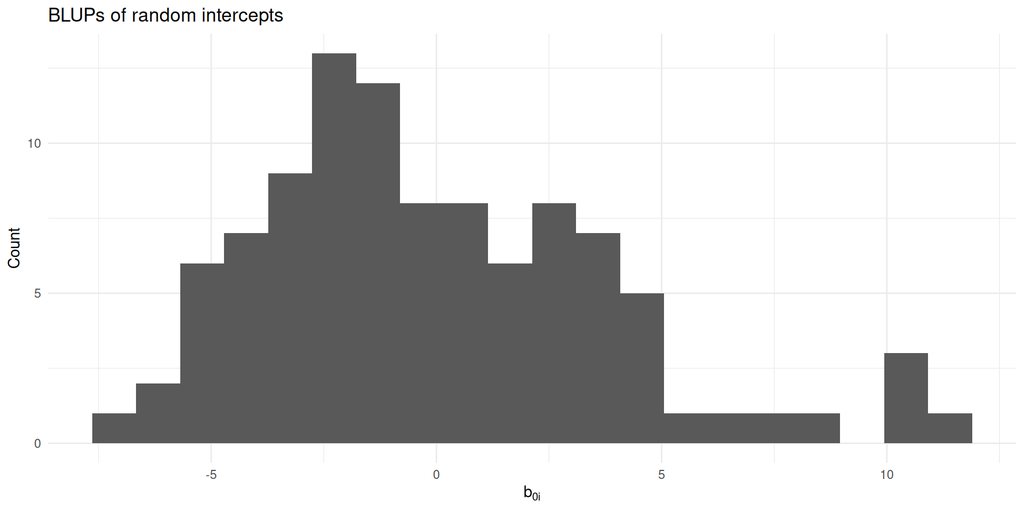

```r
re_df <- as.data.frame(re)
ggplot(re_df, aes(x = `(Intercept)`)) + geom_histogram(bins = 20) +
  labs(title = "BLUPs of random intercepts", x = expression(b[0*i]), y = "Count") +
  theme_minimal()
```

# Part II (Day 2): Extensions, Diagnostics, and Practice

## Heterogeneous Residual Variances + RI/RS

Mixed models can combine **random effects** + a **within-subject residual** covariance $R_i$:

- Heterogeneous residual SDs via `weights = varIdent(~ 1 | time_f)` (a separate residual SD per visit, instead of one constant $\sigma$)
- Additional within-subject correlation via `corAR1(~ time_num | id)` (residual AR(1): correlation that decays with the time gap) if needed

```r
lme_rifs_het <- lme(y ~ group * time_f, random = ~ time_num | id,
                    weights = varIdent(~ 1 | time_f),
                    data = tlc, method = "REML", control = ctrl)
AIC(lme_rifs, lme_rifs_het)
```

## Heterogeneous Residual Variances + RI/RS

```
             df      AIC
lme_rifs     12 2471.239
lme_rifs_het 12 2471.239
```

## Adding Residual AR(1) to RI/RS

```r
lme_rifs_ar1 <- lme(y ~ group * time_f, random = ~ time_num | id,
                    correlation = corAR1(form = ~ time_num | id),
                    data = tlc, method = "REML", control = ctrl)
data.frame(model = c("RI+RS", "RI+RS + AR(1)"),
           AIC   = c(AIC(lme_rifs), AIC(lme_rifs_ar1)))
```

Only add AR(1) if random effects **do not** remove residual serial correlation.

## Adding Residual AR(1) to RI/RS

```
          model      AIC
1         RI+RS 2471.239
2 RI+RS + AR(1) 2473.233
```

## Diagnostics: Residuals vs Fitted

```r
res <- resid(lme_rifs, type = "normalized")
fit <- fitted(lme_rifs)

ggplot(data.frame(fit, res), aes(fit, res)) +
  geom_point(alpha = 0.5) + geom_hline(yintercept = 0, linewidth = 0.3) +
  labs(title = "Residuals vs fitted (normalized)", x = "Fitted", y = "Residual") +
  theme_minimal()
```

*Normalized* residuals are Cholesky-standardized: they strip out the modeled within-subject correlation, which is why we check these (not raw residuals) for a correlated-data model.

## Diagnostics: Residuals vs Fitted

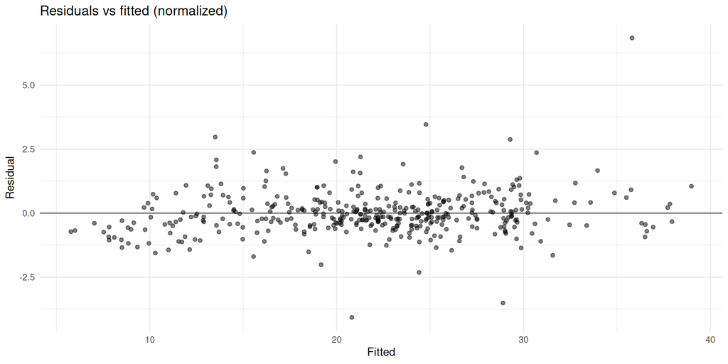

## Diagnostics: ACF of Residuals

```r
acf_out <- ACF(lme_rifs, resType = "normalized")
ggplot(acf_out, aes(lag, ACF)) + geom_col(width = 0.1) +
  geom_hline(yintercept = 0, linewidth = 0.3) +
  labs(title = "ACF of normalized residuals", x = "Lag", y = "ACF",
       subtitle = "Reading rule: bars within the band (flat) = good; slow decay = leftover serial correlation") +
  theme_minimal()
```

## Diagnostics: ACF of Residuals

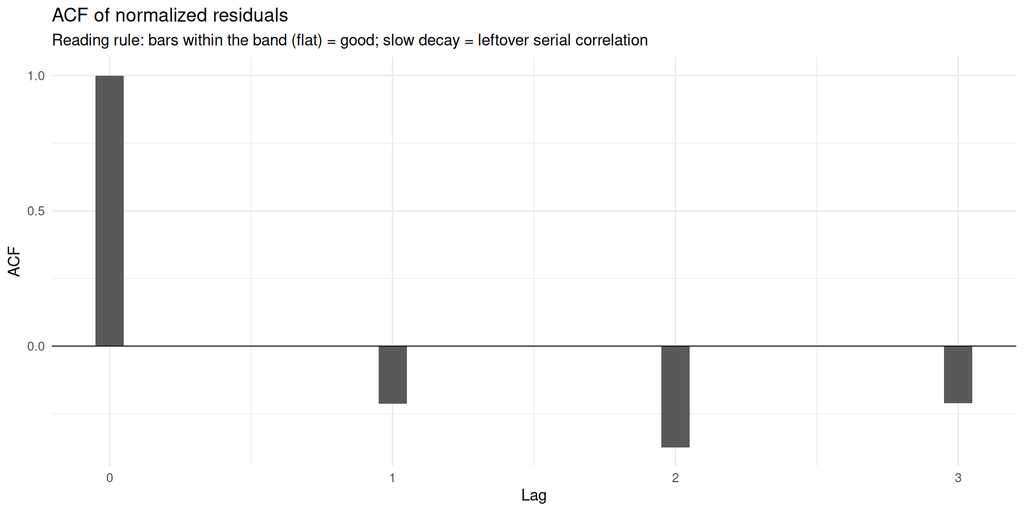

## Diagnostics: Semivariogram

```r
vg <- Variogram(lme_rifs, form = ~ time_num | id, resType = "normalized")
ggplot(vg, aes(dist, variog)) + geom_point() +
  geom_smooth(se = FALSE, span = 0.9) +
  geom_hline(yintercept = 1, linetype = 3) +
  labs(title = "Semivariogram of normalized residuals", x = "Lag (weeks apart)", y = expression(hat(gamma)),
       subtitle = "Reading rule: flat near 1 = correlation captured; rising from a low value = consider AR(1)") +
  theme_minimal()
```

## Diagnostics: Semivariogram

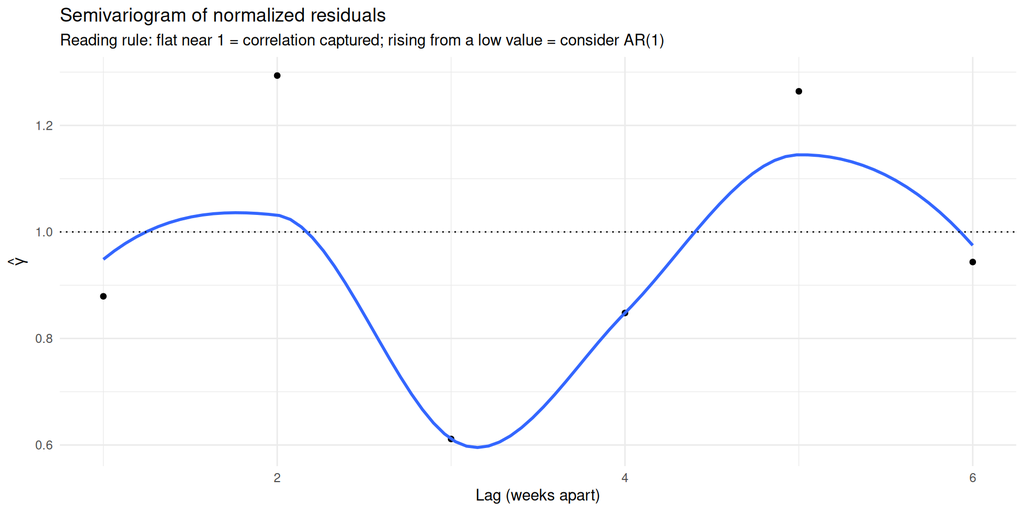

## Diagnostics: Random-Effects QQ Plot

```r
re <- ranef(lme_rifs)
qq <- as.data.frame(re)
ggplot(qq, aes(sample = `(Intercept)`)) +
  stat_qq() + stat_qq_line() +
  labs(title = "QQ plot: predicted random intercepts (BLUPs)", x = "Theoretical", y = "Sample") +
  theme_minimal()
```

**Do NOT use this to test random-effects normality**

The predicted random effects (empirical BLUPs) are **shrunk** toward 0, so their distribution **understates** the true random-effects variance and is not a valid check of the $N(0, G)$ assumption (FLW p. 273). Use the BLUP QQ plot only to **spot individual subjects with unusual profiles** (outliers/influence), never as a normality test.

## Diagnostics: Random-Effects QQ Plot

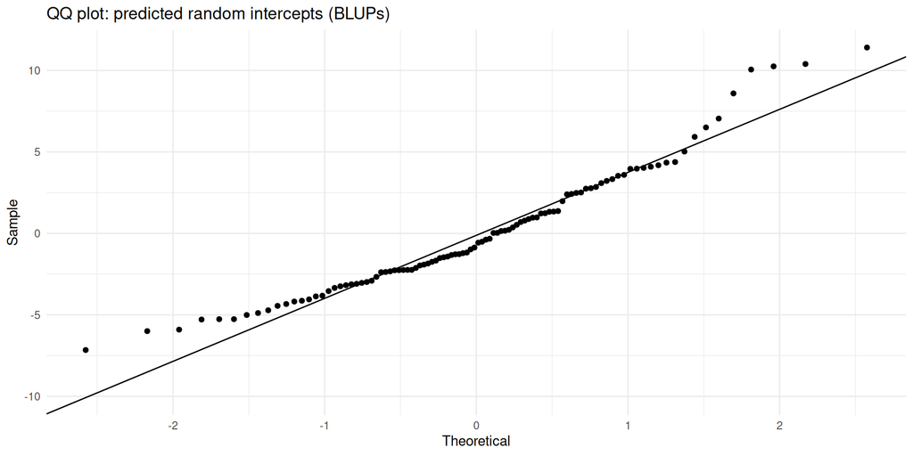

## Testing Fixed Effects

| Test Type | Method |
| --- | --- |
| Wald tests (z/F) | Large-sample z (FLW); KR/Satterthwaite df is a modern add-on |
| Likelihood-ratio tests | Between nested fixed-effects models (requires **ML** fits) |

FLW Ch. 8 uses large-sample inference: Wald z-statistics and LRTs without a small-sample df adjustment (Tables 8.5 and 8.12 report z-statistics).

**Warning**

**Beyond FLW (standard modern add-on).** Kenward-Roger and Satterthwaite df correct Wald tests in small samples but are not part of FLW Ch. 8. `nlme::lme` (used here) provides **neither**: it reports containment df. For KR/Satterthwaite, fit with `lme4::lmer` and use `lmerTest` (Satterthwaite) or `pbkrtest` (Kenward-Roger). The LRT route below works directly in `nlme` once both models are refit with ML.

```r
lme_rifs_ML <- update(lme_rifs, method = "ML")
lme_rifs_noInt_ML <- lme(y ~ group + time_f, random = ~ time_num | id, data = tlc, method = "ML", control = ctrl)
anova(lme_rifs_noInt_ML, lme_rifs_ML)
```

## Testing Fixed Effects

```
                  Model df      AIC      BIC    logLik   Test  L.Ratio p-value
lme_rifs_noInt_ML     1  9 2578.232 2614.155 -1280.116
lme_rifs_ML           2 12 2481.167 2529.064 -1228.583 1 vs 2 103.0653  <.0001
```

## Testing Variance Components (Boundary)

Variance-component tests are **boundary** tests (a variance cannot be negative), so the null distribution is a 50:50 **mixture**, not a plain $\chi^2$. Which mixture depends on how many parameters you drop:

- **One variance** (e.g. $\sigma_{b0}^2 = 0$: is a random intercept needed at all?): $\tfrac12\chi^2_0 + \tfrac12\chi^2_1$. Only here is the corrected p the naive $\chi^2_1$ p-value **halved**.
- **A random slope, dropped from a model that already has a random intercept** (our example below: removes $\sigma_{b1}^2$ **and** the intercept-slope covariance $\sigma_{b01}$, two parameters): $\tfrac12\chi^2_1 + \tfrac12\chi^2_2$ (Stram & Lee). **Not** a simple halving.

```r
lrt <- anova(lme_ri, lme_rifs)   # REML; same fixed effects, drop the random slope
lrt
```

The naive `anova()` $\chi^2_2$ p-value is **conservative** (too large). The mixture above is the correct adjustment for this two-parameter test.

**Note**

**FLW’s procedure (Section 8.5, p. 209).** Compare the LRT statistic against the 50:50 chi-squared mixture critical values in **FLW Appendix Table C.1**. For comparing **two correlated random effects (random intercept + slope) versus one (random intercept only)** – exactly this random-slope test, the $\tfrac12\chi^2_1 + \tfrac12\chi^2_2$ mixture – the $\alpha = 0.05$ critical value is the $q=1$ row of Table C.1, **5.14** (smaller than the naive $\chi^2_2$ value of 5.99). FLW recommend $\alpha = 0.10$ instead of $0.05$ only for **more complex** comparisons ($q$ vs $q+k$ correlated random effects with $k > 1$), where the null distribution is less well understood. (Testing a single variance component at 0 is the $\tfrac12\chi^2_0 + \tfrac12\chi^2_1$ case, $\alpha = 0.05$ critical value about 2.71.)

**Tip**

**Beyond FLW (modern extension).** For exact inference on a single variance component, a parametric bootstrap of the restricted LRT is available via `RLRsim::exactRLRT`; `pbkrtest` offers a parametric bootstrap LRT. These are not the chapter’s method (FLW uses the tabulated mixture above), but they avoid the asymptotic mixture approximation.

## Testing Variance Components (Boundary)

```
         Model df      AIC      BIC    logLik   Test  L.Ratio p-value
lme_ri       1 10 2480.621 2520.334 -1230.311
lme_rifs     2 12 2471.239 2518.894 -1223.620 1 vs 2 13.38185  0.0012
```

```r
# Dropping the random slope removes TWO parameters: use the 1/2 chi^2_1 + 1/2 chi^2_2 mixture
LR <- lrt[["L.Ratio"]][2]
p_mix <- 0.5 * pchisq(LR, 1, lower.tail = FALSE) + 0.5 * pchisq(LR, 2, lower.tail = FALSE)
c(naive_chisq2 = lrt[["p-value"]][2], mixture_corrected = p_mix)
```

```
     naive_chisq2 mixture_corrected
      0.001242135       0.000748103
```

## Centering Time for Interpretation

With RS, centering time at a meaningful point (e.g., baseline or mid-study) stabilizes covariance and aids interpretation:

- **Intercept** = mean response at the centering time
- **Random-intercept/slope correlation** becomes more interpretable

```r
tlc <- tlc %>% mutate(time_c = time_num - mean(time_num))
lme_rifs_c <- lme(y ~ group * time_c, random = ~ time_c | id, data = tlc, method = "REML", control = ctrl)
VarCorr(lme_rifs_c)
```

## Centering Time for Interpretation

```
id = pdLogChol(time_c)
            Variance   StdDev    Corr
(Intercept) 22.3728335 4.7299930 (Intr)
time_c       0.1017683 0.3190114 1
Residual    33.1869097 5.7608081
```

**Check Your Understanding: Model Selection and Testing**

1. You want to test whether the `group * time_f` interaction is significant. Should you use ML or REML for this comparison?
2. When testing whether to drop the random slope (i.e., testing $\sigma_{b1}^2 = 0$), why is the standard $\chi^2$ test inappropriate?
3. A colleague compares two models: one with `random = ~ 1 | id` and one with `random = ~ time | id`, but the fixed effects differ (one uses `time_f`, the other uses `time_num`). Can they use REML AIC to compare these models?

**Answers:**

1. **ML**. Use ML when comparing models with different fixed effects. REML likelihoods are not comparable across models with different fixed-effects structures.
2. Testing $\sigma_{b1}^2 = 0$ is a **boundary test** because the null places the parameter on the edge of its space (variance cannot be negative), so the null distribution is a 50:50 mixture, not a plain $\chi^2$. Dropping the random slope from a model that already has a random intercept removes **two** parameters ($\sigma_{b1}^2$ and the intercept-slope covariance $\sigma_{b01}$), so the correct mixture is $\frac{1}{2}\chi^2_1 + \frac{1}{2}\chi^2_2$, not the standard $\chi^2_2$. (Testing a single variance, e.g. whether to include a random intercept at all, gives $\frac{1}{2}\chi^2_0 + \frac{1}{2}\chi^2_1$, where halving the p-value is exact.) The standard $\chi^2$ test is conservative.
3. **No**. REML AIC is only valid for comparing models with **identical fixed effects**. Since the fixed effects differ, they cannot use REML AIC. They would need to either (a) make the fixed effects the same, or (b) use ML for both models if comparing fixed effects is the goal.

## Beyond Linear Time: Splines

```r
library(splines)
lme_spl <- lme(y ~ group * ns(time_num, df = 3),
               random = ~ time_num | id, data = tlc, method = "REML", control = ctrl)
AIC(lme_rifs, lme_spl)
```

Flexible mean over time; keep random slopes (or random spline coefficients if enough data).

## Beyond Linear Time: Splines

```
         df      AIC
lme_rifs 12 2471.239
lme_spl  12 2465.472
```

## Time-Varying Covariates (TVCs)

Mixed models handle **TVCs** naturally.

Watch out for **endogeneity** (covariate depends on past $Y_{ij}$).

Interactions with time (fixed and/or random slopes) often required.

## Missing Data (MAR) and LMMs

Under **MAR**, ML/REML estimates remain valid with an appropriate mean + random-effects structure.

LMMs use all available data without ad hoc imputation.

## Simulation: Shrinkage and EBLUPs

```r
set.seed(8)
N <- 200; m <- 3
ids <- factor(seq_len(N))
times <- 0:2
G <- matrix(c(1.0, 0.3, 0.3, 0.4), 2, 2)  # random-effects covariance (FLW's G)
sigma2 <- 1.2^2                            # residual variance

sim <- do.call(rbind, lapply(ids, function(i){
  b <- MASS::mvrnorm(1, mu = c(0,0), Sigma = G)
  tibble::tibble(id = i, time = times,
                 y = 5 + 0.6*time + b[1] + b[2]*time + rnorm(length(times), sd = sqrt(sigma2)))
}))

fit <- lme(y ~ time, random = ~ time | id, data = sim, method = "REML", control = ctrl)
blup <- ranef(fit)
head(blup)
```

Note BLUPs near 0 when subject has **little information** (shrinkage).

## Simulation: Shrinkage and EBLUPs

```
  (Intercept)        time
1  -0.1305327 -0.04763182
2  -0.9065980 -0.33083520
3   0.3090307  0.11277080
4   0.5303020  0.19351415
5  -0.6292974 -0.22963803
6   0.9350150  0.34119200
```

## Visual: Shrinkage with Few vs Many Points

```r
set.seed(81)
ids_few <- sample(levels(sim$id), 6)
pred <- expand.grid(id = ids_few, time = seq(0,2,by=.05))
pred$pop <- predict(fit, newdata = pred, level = 0)
pred$ss  <- predict(fit, newdata = pred, level = 1)

ggplot(sim %>% dplyr::filter(id %in% ids_few),
       aes(time, y, group = id)) +
  geom_point() +
  geom_line(aes(y = pop, group = id), data = pred, linetype = 2) +
  geom_line(aes(y = ss,  group = id), data = pred) +
  facet_wrap(~ id, ncol = 3) +
  labs(title = "Shrinkage stronger with sparse/noisy subjects", x = "Time", y = "Y") +
  theme_minimal()
```

## Visual: Shrinkage with Few vs Many Points

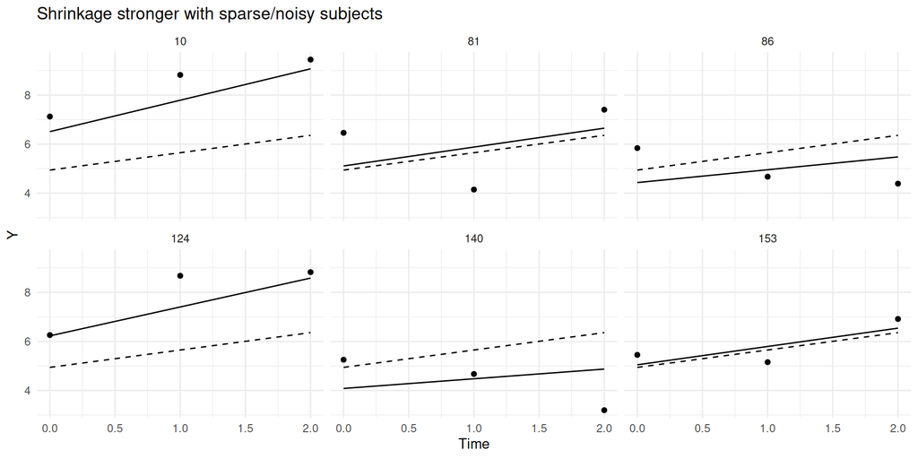

**Check Your Understanding: Shrinkage and BLUPs**

1. What are the three conditions that make shrinkage stronger (i.e., pull subject-specific estimates more toward the population mean)?
2. What is the difference between a BLUP and an EBLUP?
3. In `predict(fit, level = 0)` vs `predict(fit, level = 1)`, which one incorporates the subject-specific random effects?

**Answers:**

1. Shrinkage is stronger when: (a) the subject has **few measurements**, (b) the residual error $\sigma^2$ is **large**, and (c) the random-effect variance is **small**. In each case, subject-specific data is less informative, so we borrow more from the population.
2. **BLUP** (Best Linear Unbiased Predictor) assumes variance components are known. **EBLUP** (Empirical BLUP) uses estimated variance components from the data. In practice, we always compute EBLUPs since true variances are unknown.
3. `level = 1` gives subject-specific predictions that include the BLUPs. `level = 0` gives population-average predictions using only the fixed effects. The solid lines (level=1) in the shrinkage plot follow individual patterns; dashed lines (level=0) show the overall population trend.

## Prediction and Intervals

| Level | What It Uses |
| --- | --- |
| **Population-level** (level = 0) | Fixed effects only |
| **Subject-specific** (level = 1) | Includes BLUPs |

**Prediction intervals** require accounting for **both** residual and random-effect uncertainty, so there is no one-line `predict()` interval for a subject-specific prediction. The standard route (stated as reference, not run here):

**Note**

**Parametric-bootstrap prediction interval (recipe).** (1) Simulate new random effects $\mathbf{b}^\ast \sim N(0,\hat G)$ and residuals $\varepsilon^\ast \sim N(0,\hat\sigma^2)$ from the fitted model; (2) form $y^\ast = \mathbf{X}\hat{\boldsymbol\beta} + \mathbf{Z}\mathbf{b}^\ast + \varepsilon^\ast$ for the target subject and time; (3) repeat many times and take empirical quantiles. `lme4::bootMer` automates this for `lmer` fits; for `nlme`, simulate from `VarCorr`/`ranef` by hand.

## Influence and Outliers

- Check **standardized residuals**, **random-effect outliers**, leverage
- Consider **robust** mixed models or transformations if heavy tails/outliers

## Random-Effects Covariance Interpretation

| Component | Interpretation |
| --- | --- |
| $\sigma_{b0}^2$ | Between-subject variance at the centered time |
| $\sigma_{b1}^2$ | Heterogeneity in slopes |
| $\sigma_{b01}$ | Intercept-slope association (positive means high baseline with steeper increase) |

## When to Add Residual Correlation

If RI/RS + heterogeneous residual variances still leave **serial correlation** in residuals (ACF/variogram), add `corAR1` or similar.

Do not over-layer: random slopes often **absorb** a lot of serial correlation.

## Practical Modeling Sequence

| Step | Action |
| --- | --- |
| 1 | Choose **rich mean** (time as factor or spline; group x time) |
| 2 | Start with **RI**; consider **RS** if trajectories differ in slope |
| 3 | Add **heterogeneous residual SDs** if needed; check residual ACF/variogram |
| 4 | Only then consider additional residual correlation (e.g., AR(1)) |
| 5 | Compare **REML AIC** for random/residual structures; **ML** for fixed effects |
| 6 | Validate with residual and random-effect diagnostics |

## Class Exercise Prompt (TLC)

1. Fit: RI, RI+RS, RI+RS+varIdent
2. Compare by REML AIC; interpret variance components
3. Report group differences at each visit (EMMs) with 95% CIs

## Code Template for Exercise

```r
# 1) RI
fit_ri <- lme(y ~ group * time_f, random = ~ 1 | id, data = tlc, method = "REML")

# 2) RI+RS (time_num in random part)
fit_rs <- lme(y ~ group * time_f, random = ~ time_num | id, data = tlc, method = "REML", control = ctrl)

# 3) Add hetero residual SDs by visit
fit_rs_het <- update(fit_rs, weights = varIdent(~ 1 | time_f))

# Compare REML AIC
data.frame(model=c("RI","RI+RS","RI+RS+het"),
           AIC=c(AIC(fit_ri), AIC(fit_rs), AIC(fit_rs_het)))
```

## Code Template for Exercise

```
      model      AIC
1        RI 2480.621
2     RI+RS 2471.239
3 RI+RS+het 2471.239
```

```r
# EMMs: group contrasts by visit
emmeans(fit_rs_het, ~ group | time_f) |> pairs()
```

```
time_f = 0:
 contrast           estimate   SE df t.ratio p.value
 Placebo - Succimer   -0.268 1.17 98  -0.229  0.8196

time_f = 1:
 contrast           estimate   SE df t.ratio p.value
 Placebo - Succimer   11.138 1.22 98   9.111 <0.0001

time_f = 4:
 contrast           estimate   SE df t.ratio p.value
 Placebo - Succimer    8.556 1.38 98   6.185 <0.0001

time_f = 6:
 contrast           estimate   SE df t.ratio p.value
 Placebo - Succimer    2.884 1.50 98   1.926  0.0570

Degrees-of-freedom method: containment
```

## Common Pitfalls

| Pitfall | Correct Approach |
| --- | --- |
| Comparing random structures under ML | Use REML |
| Boundary tests with plain $\chi^2$ | Use mixture or bootstrap |
| Ignoring centering for RS | Leads to awkward intercept/slope correlation |
| High-degree polynomials for time | Prefer splines |

## Common Mistakes to Avoid

**Mistakes That Lead to Wrong Results**

[output not shown]

## RI/RS vs Pure Covariance Models (Ch. 7)

- Many covariance patterns can be **mimicked** by random effects
- Mixed models **interpret** $\Sigma_i$ through heterogeneity in **baseline/slopes**
- For prediction and patient-specific effects, **mixed models** are natural

## Reporting Checklist (LMM)

| Element | Details |
| --- | --- |
| Mean structure | Time coding, interactions, rationale |
| Random structure | RI/RS; covariance of random effects $G$ |
| Residual structure | Heterogeneous SDs, AR(1) if any |
| Estimation method | ML/REML and model comparisons |
| Estimates | Fixed effects with CIs; variance components |
| Diagnostics | Residual ACF/variogram; BLUP plot for unusual subjects (not RE normality); influence |
| Sensitivity | Additional analyses |

## Quick Reference: `nlme::lme` Syntax

```r
# Random-intercept
lme(y ~ fixed_terms, random = ~ 1 | id, data = dat)

# Random-slope (linear time)
lme(y ~ fixed_terms, random = ~ time | id, data = dat)

# Add hetero residual SDs by visit
lme(y ~ fixed_terms, random = ~ time | id,
    weights = varIdent(~ 1 | time_factor), data = dat)

# Add residual AR(1)
lme(y ~ fixed_terms, random = ~ time | id,
    correlation = corAR1(~ time | id), data = dat)
```

## The Same Model in SAS (PROC MIXED)

R is our runnable language (used in the slides above and in the homework). For students who work in SAS, here is the equivalent, shown for reference only and not executed. This mirrors FLW’s Computing section (8.9).

```sas
/* Not run here. SAS counterpart of the random-slope fit above, on the TLC data. */
PROC MIXED DATA=tlc METHOD=REML;
  CLASS id trt;
  MODEL y = time trt time*trt / SOLUTION;
  RANDOM intercept time / SUBJECT=id TYPE=UN G;
RUN;
```

- `RANDOM ... / SUBJECT=id` is the SAS counterpart of R’s `random = ~ time | id` (or `(time | id)` in `lmer`).
- `METHOD=REML` matches the `nlme::lme`/`lmer` default; use `METHOD=ML` for LRTs of fixed effects.
- `TYPE=UN` is an unstructured $G$ (correlated intercept and slope); `TYPE=VC` makes them independent.

## Quick Reference: ML vs REML

| Goal | Method |
| --- | --- |
| Compare fixed effects | Refit both models with **ML**; LRT/AIC on ML |
| Choose random/residual structure | Fit with **REML**; compare REML AIC/LRT |

## Side Note: lme vs lmer

| Package | Strengths |
| --- | --- |
| `nlme::lme` | Residual correlation structures and heteroscedastic weights; no built-in Satterthwaite |
| `lme4::lmer` | Fast, robust; pair with `lmerTest` for df; no built-in residual AR(1)/varIdent |

Choose based on needs; results for fixed effects are often similar.

## Worked Example: ML vs REML

```r
fit_full_ML <- lme(y ~ group * time_f, random = ~ time_num | id, data = tlc, method = "ML", control = ctrl)
fit_noint_ML <- lme(y ~ group + time_f, random = ~ time_num | id, data = tlc, method = "ML", control = ctrl)
anova(fit_noint_ML, fit_full_ML)
```

## Worked Example: ML vs REML

```
             Model df      AIC      BIC    logLik   Test  L.Ratio p-value
fit_noint_ML     1  9 2578.232 2614.155 -1280.116
fit_full_ML      2 12 2481.167 2529.064 -1228.583 1 vs 2 103.0653  <.0001
```

## Subject-Specific Predictions Table

```r
sub_ids <- head(levels(tlc$id), 6)
new6 <- tlc %>% distinct(id, group) %>% filter(id %in% sub_ids) %>%
  mutate(time_num = 6, time_f = factor("6", levels = c("0","1","4","6")))
data.frame(
  id = sub_ids,
  pop = predict(lme_rifs, newdata = new6, level = 0),
  ss  = predict(lme_rifs, newdata = new6, level = 1)
)
```

## Subject-Specific Predictions Table

```
  id    pop       ss
1  1 23.646 25.63256
2  2 20.762 22.22903
3  3 20.762 24.51969
4  4 23.646 22.34439
5  5 20.762 10.05191
6  6 20.762 11.78730
```

## Model Criticism: Overdispersion/Heavy Tails

If residuals or random effects are heavy-tailed, consider:

- Transformations, variance functions, robust LMMs (e.g., t-distributed random effects/errors)
- Check sensitivity to outliers

## Time as Factor vs Continuous: Guidance

| Approach | Best For |
| --- | --- |
| **Factor** | Flexible at planned visits; good for EMMs at specific times |
| **Continuous** | Interpretable global slope; good with many time points or mistiming |
| **Combined** | Factor in fixed, continuous in random (RS) is often optimal |

## Growth Curves vs Spline LMMs

- Polynomial growth curves are easy but can oscillate
- Natural cubic **splines** are more stable
- Choose df by AIC/CV and subject-matter considerations

## TVCs and Lagged Effects

- Incorporate **lagged** covariates if plausible causal ordering
- Beware of **post-treatment** covariates when estimating treatment effects

## Beyond Gaussian LMMs

- GLMMs for non-Gaussian outcomes (binary, counts)
- Similar principles; estimation via Laplace/AGQ
- Not covered in this chapter

## Cheat-Sheet: Model Choice

| Question | Solution |
| --- | --- |
| Slopes differ across subjects? | Add RS |
| Residual SD varies by visit? | Add varIdent |
| Leftover serial correlation? | Add AR(1) |
| Need predictions per subject? | Use Mixed models |
| Only marginal contrasts? | Consider GEE as sensitivity |

## Cheat-Sheet: Testing

| Test Type | Method |
| --- | --- |
| Fixed effects | ML for model comparison; large-sample Wald z / LRT (FLW). KR/Satterthwaite df is a modern add-on |
| Random effects | REML LRT vs the 50:50 mixture (FLW Appendix Table C.1; use $\alpha = 0.10$ for $q$-vs-$q+k$, $k>1$). Bootstrap is beyond FLW |

Do not mix ML and REML across compared models.

## What to Include in Your Report

- Data structure and missingness; time coding
- Final mean, random, residual structures; estimation method
- Key estimates (fixed) with CIs; variance components
- Diagnostics; sensitivity; clear interpretations

## Recipe Card: Fitting Mixed-Effects Models

**Step-by-Step Workflow for LMM Analysis**

**Step 1: Data Preparation**

```r
# Ensure data is in long format with:
# - Subject ID as factor
# - Time as both factor (for rich mean) and numeric (for slopes)
dat <- dat %>%
  mutate(id = factor(id),
         time_f = factor(time),
         time_num = as.numeric(time),
         time_c = time_num - mean(time_num))  # centered
```

**Step 2: Fit Candidate Models (REML)**

```r
# Start with random intercept
fit_ri <- lme(y ~ group * time_f, random = ~ 1 | id,
              data = dat, method = "REML")

# Add random slope
fit_rs <- lme(y ~ group * time_f, random = ~ time_num | id,
              data = dat, method = "REML")

# Add heterogeneous residual variances
fit_rs_het <- update(fit_rs, weights = varIdent(~ 1 | time_f))
```

**Step 3: Compare Random Structures (REML AIC)**

```r
AIC(fit_ri, fit_rs, fit_rs_het)  # Lower is better
```

**Step 4: Check Diagnostics**

```r
plot(fit_rs)                    # Residuals vs fitted
qqnorm(resid(fit_rs, type = "normalized"))
ACF(fit_rs)                     # Check for leftover correlation
qqnorm(ranef(fit_rs)[,1])       # BLUPs: spot unusual subjects, NOT a normality test (FLW p.273)
```

**Step 5: Test Fixed Effects (refit with ML)**

```r
fit_full_ML <- update(fit_rs, method = "ML")
fit_reduced_ML <- lme(y ~ group + time_f, random = ~ time_num | id,
                      data = dat, method = "ML")
anova(fit_reduced_ML, fit_full_ML)  # LRT for interaction
```

**Step 6: Report Final Model**

```r
summary(fit_rs)$tTable           # Fixed effects
VarCorr(fit_rs)                  # Variance components
emmeans(fit_rs, ~ group | time_f) %>% pairs()  # Contrasts
```

## Summary: Big Ideas

1. **Mixed-effects** = flexible, interpretable way to model individual trajectories and covariance
2. **Shrinkage** improves estimation for sparse/noisy subjects
3. Careful **model comparison** (ML vs REML) and **boundary-aware** tests are crucial

## Further Reading and For Next Time

- **FLW Ch. 8:** the Case Studies (8.8), the Computing section on PROC MIXED (8.9), and Further Reading (8.10).
- Laird & Ware (1982), the original two-stage random-effects formulation behind 8.4.
- **Next:** FLW Ch. 9, Fixed Effects versus Random Effects Models and the Hausman test (Lecture 9).

**Note**

**A note on the data.** TLC is our **course running example** (carried over from Ch. 5-7 for continuity), not a Ch. 8 dataset. FLW Ch. 8’s own case studies (Section 8.8) are the **Six Cities** log(FEV1) data, fit with hybrid random-effects + serial-correlation models, and the **ACTG 193A** log(CD4) counts, fit with a linear-spline LME whose empirical-BLUP trajectories appear in Fig. 8.10.